# Prediction Assignment

Sebastian Castillo

2019-01-03

# INTRODUCTION

This is the final report of the Peer Assessment project from the Practical Machine Learning course, which is a part of the Data Science Specialization. The goal of the project was to fit a Machine Learning model in order to predict the way some weight exercises were performed given data about the movement of subjects.The machine learning algorithm, which uses the classe variable in the training set, is applied to the 20 test cases available in the test data.

The training data for this project are available here: [link](https://d396qusza40orc.cloudfront.net/predmachlearn/pml-training.csv)

The test data are available here: [link](https://d396qusza40orc.cloudfront.net/predmachlearn/pml-testing.csv)

# Understanding the Data

Devices such as Jawbone Up, Nike FuelBand, and Fitbit can enable collecting a large amount of data about someone’s physical activity. These devices are used by the enthusiasts who take measurements about themselves regularly to improve their health, to find patterns in their behavior, or because they are tech geeks. However, even though these enthusiasts regularly quantify how much of a particular activity they do, they rarely quantify how well they do it. In this project, the goal is to use data from accelerometers on the belt, forearm, arm, and dumbell of six participants. They were asked to perform barbell lifts correctly and incorrectly in five different ways.

# Load the dataset

Create two partitions (75 % and 25 %) within the original training dataset.

```
## [1] 14718   160
```

```
## [1] 4904  160
```

The two datasets have a large number of NA values as well as near-zero-variance variables, so they will be removed.

```
## [1] 14718   117
```

```
## [1] 4904  117
```

Remove variables that are mostly NA. A threshlod of 95 % is selected.

Columns 1 to 5 are identification variables only, they will be removed.

```
## [1] 14718    54
```

```
## [1] 4904   54
```

The number of variables for the analysis has been reduced from 160 to 54.

# Correlation Analysis

Perform a correlation analysis between the variables before the modeling work itself is done. Select “FPC” for the first principal component order.

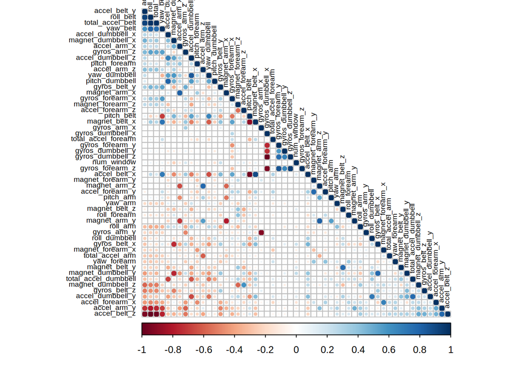

# Fitting prediction models

In this part three different models will be fitted to the trainingdata (and evaluated against the testdata).

# Random Forest (RF)

```
## Confusion Matrix and Statistics
##
##           Reference
## Prediction    A    B    C    D    E
##          A 1395    2    0    0    0
##          B    0  947    3    0    0
##          C    0    0  852    1    0
##          D    0    0    0  803    1
##          E    0    0    0    0  900
##
## Overall Statistics
##
##                Accuracy : 0.9986
##                  95% CI : (0.9971, 0.9994)
##     No Information Rate : 0.2845
##     P-Value [Acc > NIR] : < 2.2e-16
##
##                   Kappa : 0.9982
##  Mcnemar's Test P-Value : NA
##
## Statistics by Class:
##
##                      Class: A Class: B Class: C Class: D Class: E
## Sensitivity            1.0000   0.9979   0.9965   0.9988   0.9989
## Specificity            0.9994   0.9992   0.9998   0.9998   1.0000
## Pos Pred Value         0.9986   0.9968   0.9988   0.9988   1.0000
## Neg Pred Value         1.0000   0.9995   0.9993   0.9998   0.9998
## Prevalence             0.2845   0.1935   0.1743   0.1639   0.1837
## Detection Rate         0.2845   0.1931   0.1737   0.1637   0.1835
## Detection Prevalence   0.2849   0.1937   0.1739   0.1639   0.1835
## Balanced Accuracy      0.9997   0.9986   0.9981   0.9993   0.9994
```

## Plot RF

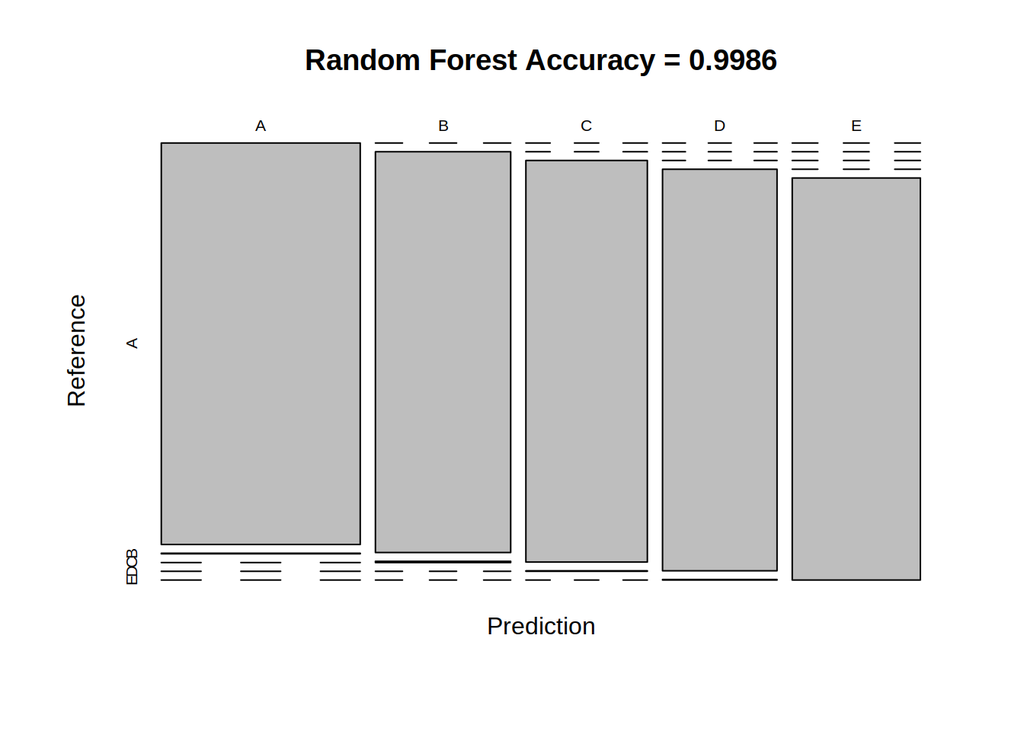

## Linear Discriminant Analysis (LDA)

```
## Confusion Matrix and Statistics
##
##           Reference
## Prediction    A    B    C    D    E
##          A 1155  122   88   53   49
##          B   30  627   73   33  141
##          C   88  115  564   98   87
##          D  119   37  106  581   75
##          E    3   48   24   39  549
##
## Overall Statistics
##
##                Accuracy : 0.7088
##                  95% CI : (0.6959, 0.7215)
##     No Information Rate : 0.2845
##     P-Value [Acc > NIR] : < 2.2e-16
##
##                   Kappa : 0.6313
##  Mcnemar's Test P-Value : < 2.2e-16
##
## Statistics by Class:
##
##                      Class: A Class: B Class: C Class: D Class: E
## Sensitivity            0.8280   0.6607   0.6596   0.7226   0.6093
## Specificity            0.9111   0.9300   0.9042   0.9178   0.9715
## Pos Pred Value         0.7873   0.6936   0.5924   0.6329   0.8281
## Neg Pred Value         0.9302   0.9195   0.9264   0.9441   0.9170
## Prevalence             0.2845   0.1935   0.1743   0.1639   0.1837
## Detection Rate         0.2355   0.1279   0.1150   0.1185   0.1119
## Detection Prevalence   0.2991   0.1843   0.1941   0.1872   0.1352
## Balanced Accuracy      0.8695   0.7953   0.7819   0.8202   0.7904
```

## Plot LDA

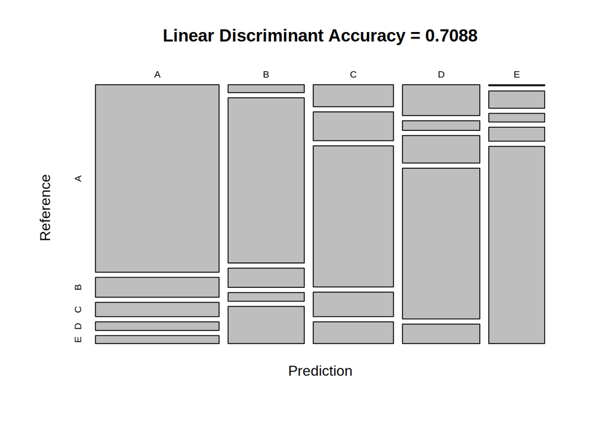

## K Nearest Neighbor (KNN)

```
## Confusion Matrix and Statistics
##
##           Reference
## Prediction    A    B    C    D    E
##          A 1345   35   14   10   10
##          B   15  843   35    1   26
##          C    9   32  787   43   14
##          D   24   20   16  742   29
##          E    2   19    3    8  822
##
## Overall Statistics
##
##                Accuracy : 0.9256
##                  95% CI : (0.9179, 0.9328)
##     No Information Rate : 0.2845
##     P-Value [Acc > NIR] : < 2.2e-16
##
##                   Kappa : 0.9058
##  Mcnemar's Test P-Value : 4.451e-11
##
## Statistics by Class:
##
##                      Class: A Class: B Class: C Class: D Class: E
## Sensitivity            0.9642   0.8883   0.9205   0.9229   0.9123
## Specificity            0.9803   0.9805   0.9758   0.9783   0.9920
## Pos Pred Value         0.9512   0.9163   0.8893   0.8929   0.9625
## Neg Pred Value         0.9857   0.9734   0.9831   0.9848   0.9805
## Prevalence             0.2845   0.1935   0.1743   0.1639   0.1837
## Detection Rate         0.2743   0.1719   0.1605   0.1513   0.1676
## Detection Prevalence   0.2883   0.1876   0.1805   0.1695   0.1741
## Balanced Accuracy      0.9722   0.9344   0.9481   0.9506   0.9522
```

Plot KNN

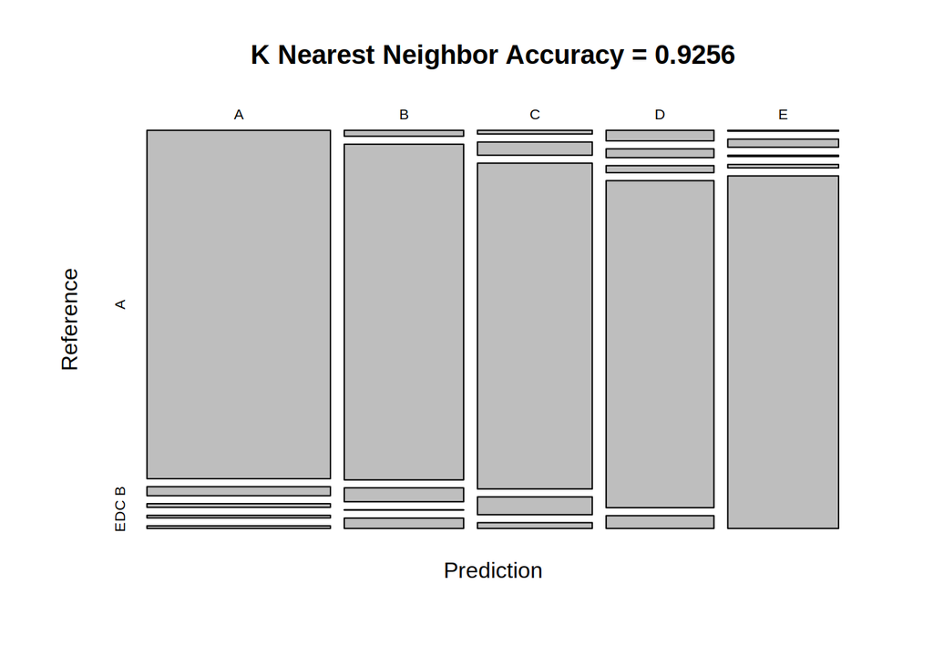

## Final Prediction on the test set

All models were trained with crossvalidation.

Sorted on performance to predict the test data, the ranking of the different models is as follows:

*1: 0.9986 (Random Forest)*  
2: 0.9256 (KNN)  
*3: 0.7088 (LDA)

On accuracy, Random Forest is a clear winner. And it is clear from the corresponding plot that all categories of classe are more or less equally predicted.

So for the final prediction on the extra test-set the final Random Forest model is choosen.

[output not shown]

[output cut: 131 more lines]